# CURA_CARLOS-PS2

# The optimal depth would be any less than 11.

## 2.2 Minimum sample size to split

### 2.2.1

Explain what the min_sample_split parameter does. Do large or small values lead to overfitting?

```python
#Its the hyperparatmer that decides the minimum value of entities that are needed to divide/split nodes during the trees creation phase.
#Its a determinant to notify when a node needs to divide its children nodes.
#Its minimum  value needed to stop leaf nodes.
#Small values lead to overfitting
```

### 2.2.2

Run a series of decision tree models with different min_sample_split values in a loop. Try to cover both underfitting and overfitting. Each time store both validation and training accuracy. Make a plot where you show how both training and validation accuracy depend on the parameter.

```python
#1


results_trainList4 = []
results_testList4 = []
for depth in range(2,20,1):
    np.random.seed(1000)
    clf_dt = make_pipeline( StandardScaler(), tree.DecisionTreeClassifier(min_samples_split=depth))

    accuracy_resultsTrain4 = cross_val_score(clf_dt, X_train2, y_train2, cv=5, scoring = "accuracy")
    accuracy_resultsTest4 = cross_val_score(clf_dt, X_test2, y_test2, cv=5, scoring = "accuracy")

    results_trainList4.append([depth, 100 * np.mean(accuracy_resultsTrain4)])


    results_testList4.append([depth, 100 * np.mean(accuracy_resultsTest4)])


df_results_list_dtTrain4 = pd.DataFrame(results_trainList4, columns=["Min_Samples_Split", "Acc"])
df_results_list_dtTest4 = pd.DataFrame(results_testList4, columns=["Min_Samples_Split", "Acc"])
```

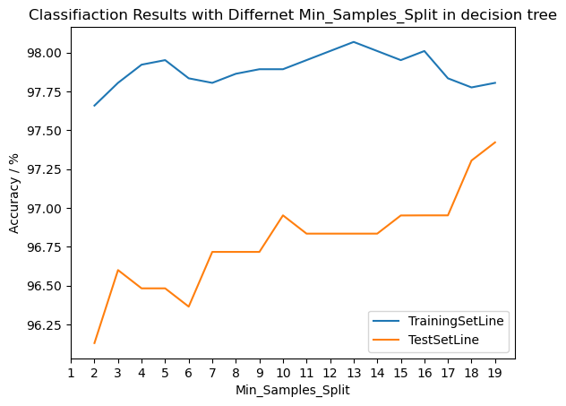

```python
fig, ax = plt.subplots()
df_results_list_dtTrain4.set_index("Min_Samples_Split")["Acc"].plot(ax = ax, label='TrainingSetLine')
df_results_list_dtTest4.set_index("Min_Samples_Split")["Acc"].plot(ax = ax, label='TestSetLine')
ax.set_title("Classifiaction Results with Differnet Min_Samples_Split in decision tree")
ax.set_xticks(list(range(1,20,1)))
ax.set_ylabel("Accuracy / %")

ax.legend()

plt.show()
```

```python
#2


results_trainList5 = []
results_testList5 = []
for depth in range(2,30,1):
    np.random.seed(1000)
    clf_dt = make_pipeline( StandardScaler(), tree.DecisionTreeClassifier(min_samples_split=depth))

    accuracy_resultsTrain5 = cross_val_score(clf_dt, X_train2, y_train2, cv=5, scoring = "accuracy")
    accuracy_resultsTest5 = cross_val_score(clf_dt, X_test2, y_test2, cv=5, scoring = "accuracy")

    results_trainList5.append([depth, 100 * np.mean(accuracy_resultsTrain5)])


    results_testList5.append([depth, 100 * np.mean(accuracy_resultsTest5)])


df_results_list_dtTrain5 = pd.DataFrame(results_trainList5, columns=["Min_Samples_Split", "Acc"])
df_results_list_dtTest5 = pd.DataFrame(results_testList5, columns=["Min_Samples_Split", "Acc"])
```

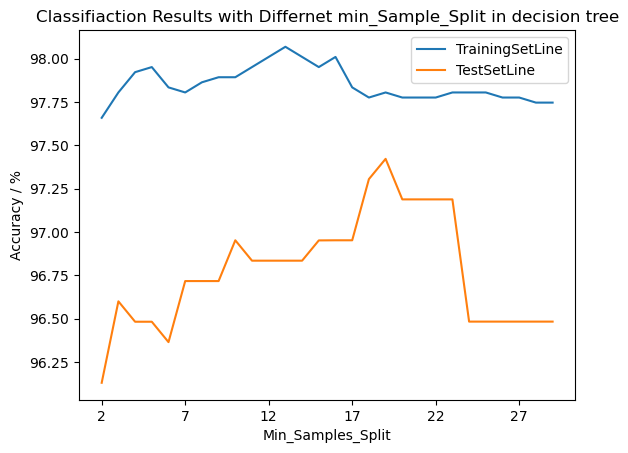

```python
fig, ax = plt.subplots()
df_results_list_dtTrain5.set_index("Min_Samples_Split")["Acc"].plot(ax = ax, label='TrainingSetLine')
df_results_list_dtTest5.set_index("Min_Samples_Split")["Acc"].plot(ax = ax, label='TestSetLine')
ax.set_title("Classifiaction Results with Differnet min_Sample_Split in decision tree")
ax.set_xticks(list(range(2,30,5)))
ax.set_ylabel("Accuracy / %")

ax.legend()

plt.show()
```

```python
#3

results_trainList35 = []
results_testList35 = []
for depth in range(2, 500,50):
    np.random.seed(1000)
    clf_dt = make_pipeline( StandardScaler(), tree.DecisionTreeClassifier(min_samples_split=depth))

    accuracy_resultsTrain35 = cross_val_score(clf_dt, X_train2, y_train2, cv=5, scoring = "accuracy")
    accuracy_resultsTest35 = cross_val_score(clf_dt, X_test2, y_test2, cv=5, scoring = "accuracy")

    results_trainList35.append([depth, 100 * np.mean(accuracy_resultsTrain35)])


    results_testList35.append([depth, 100 * np.mean(accuracy_resultsTest35)])


df_results_list_dtTrain35 = pd.DataFrame(results_trainList35, columns=["Min_Samples_Split", "Acc"])
df_results_list_dtTest35 = pd.DataFrame(results_testList35, columns=["Min_Samples_Split", "Acc"])
```

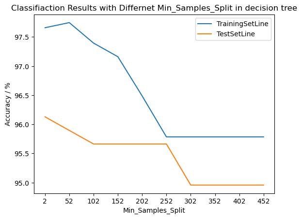

```python
fig, ax = plt.subplots()
df_results_list_dtTrain35.set_index("Min_Samples_Split")["Acc"].plot(ax = ax, label='TrainingSetLine')
df_results_list_dtTest35.set_index("Min_Samples_Split")["Acc"].plot(ax = ax, label='TestSetLine')
ax.set_title("Classifiaction Results with Differnet Min_Samples_Split in decision tree")
ax.set_xticks(list(range(2,500,50)))
ax.set_ylabel("Accuracy / %")

ax.legend()

plt.show()
```

### 2.2.3

# What is the best validation accuracy you get? What is the corresponding min_sample_split?

##### **Answer: The best validation accuracy I get is around 97.4% with a min_sample split of 19**

### 2.2.4

Discuss your findings: where does the model start overfitting?

### 2.2.5

Write a double loop over both parameters.Try to pick a number of values not too differentf rom what you found above when analyzing those individually. Store the best result and the respective parameters.

```python
#Combine the maximum and min_sample_splits
```

```python
respectiveParameter = []

#best accuracy result starter
accuracy = 0


for depth in range(2, 100,10):
    for min_sample_split in range(2, 100, 10):
        np.random.seed(1000)
        clf_dt = make_pipeline(StandardScaler(), tree.DecisionTreeClassifier(max_depth=depth, min_samples_split=min_sample_split))

        accuracyResults = cross_val_score(clf_dt, X_test2, y_test2, cv=5, scoring = "accuracy")

        meanAccuracy =  100 * np.mean(accuracyResults)

        #apply a checking system to find best accuracy
        if meanAccuracy > accuracy:
            accuracy = meanAccuracy
            respectiveParameter = [depth, min_sample_split]

print(f"Best Parameter : {respectiveParameter}")

print(f"Best Result : {accuracy}")
```

```
Best Parameter : [12, 22]
Best Result : 97.18747850017199
```

# 3 - Random Forests

## 3.1 Explain what the n_estimators parameter does.

Answer: n_estimators is the hyperparamter that takes into account the amount of decision trees in a random forest.

## 3.2 Run a series of random forest classifiers testing what is the best number of estimators.

This may be slow, so you may want to skip quite a few potential values.

```python
y_cols2 = ["loan_status"]

X_full2 = loanApproval[x_cols2]

y_full2 = loanApproval[y_cols2]

cv_split2 = KFold(n_splits=5, shuffle=True, random_state=371)
```

```python
# Classififer 6

results_trainList6 = []
results_testList6 = []
for n_estimator in range(5,55,5):
    np.random.seed(100)
    depth = 3
    clf_rf = ensemble.RandomForestClassifier(
        n_estimators= n_estimator,
        max_depth = depth)
    accuracy_resultsTrain6 = cross_val_score(clf_rf, X_train2, y_train2.values.ravel(), cv=5, scoring = "accuracy")
    accuracy_resultsTest6 = cross_val_score(clf_rf, X_train2, y_train2.values.ravel(), cv=5, scoring = "accuracy")


    results_trainList6.append([n_estimator, 100 * np.mean(accuracy_resultsTrain6)])
    results_testList6.append([n_estimator, 100 * np.mean(accuracy_resultsTest6)])


df_results_list_dtTrain6 = pd.DataFrame(results_trainList6, columns=["n_estimator", "Acc"])
df_results_list_dtTest6 = pd.DataFrame(results_testList6, columns=["n_estimator", "Acc"])
```

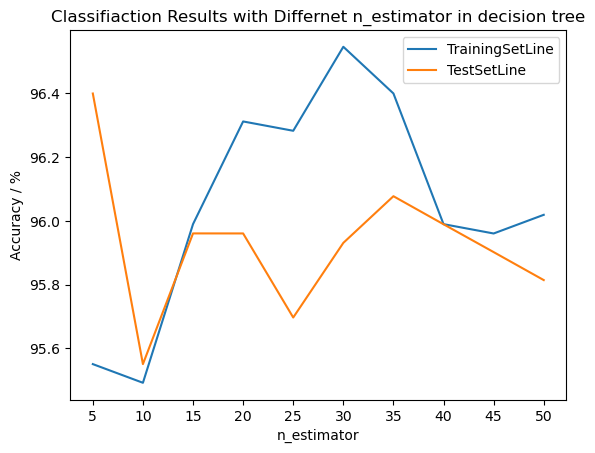

```python
fig, ax = plt.subplots()
df_results_list_dtTrain6.set_index("n_estimator")["Acc"].plot(ax = ax, label='TrainingSetLine')
df_results_list_dtTest6.set_index("n_estimator")["Acc"].plot(ax = ax, label='TestSetLine')
ax.set_title("Classifiaction Results with Differnet n_estimator in decision tree")
ax.set_xticks(list(range(5,55,5)))
ax.set_ylabel("Accuracy / %")

ax.legend()

plt.show()
```

```python
#Classifier 7
results_trainList7 = []
results_testList7 = []
for n_estimator in range(5, 200, 10):
    np.random.seed(100)
    depth = 3
    clf_rf = ensemble.RandomForestClassifier(
        n_estimators= n_estimator,
        max_depth = depth)
    accuracy_resultsTrain7 = cross_val_score(clf_rf, X_train2, y_train2.values.ravel(), cv=5, scoring = "accuracy")
    accuracy_resultsTest7 = cross_val_score(clf_rf, X_train2, y_train2.values.ravel(), cv=5, scoring = "accuracy")


    results_trainList7.append([n_estimator, 100 * np.mean(accuracy_resultsTrain7)])
    results_testList7.append([n_estimator, 100 * np.mean(accuracy_resultsTest7)])


df_results_list_dtTrain7 = pd.DataFrame(results_trainList7, columns=["n_estimator", "Acc"])
df_results_list_dtTest7 = pd.DataFrame(results_testList7, columns=["n_estimator", "Acc"])

ax.legend()

plt.show()
```

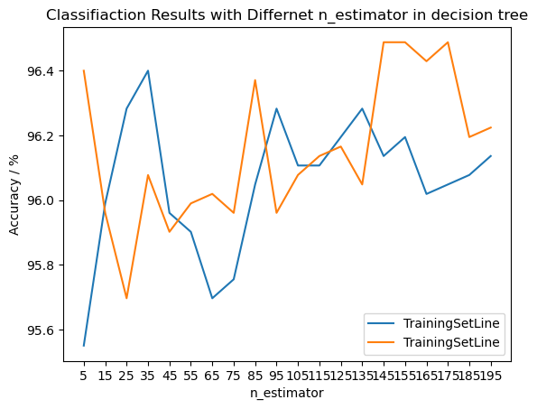

```python
#Classifier 7 plot

fig, ax = plt.subplots()
df_results_list_dtTrain7.set_index("n_estimator")["Acc"].plot(ax = ax, label='TrainingSetLine')
df_results_list_dtTest7.set_index("n_estimator")["Acc"].plot(ax = ax, label='TrainingSetLine')
ax.set_title("Classifiaction Results with Differnet n_estimator in decision tree")
ax.set_xticks(list(range(5,200,10)))
ax.set_ylabel("Accuracy / %")

ax.legend()

plt.show()
```

```python
#Classifier 8
results_trainList8 = []
results_testList8 = []
for n_estimator in range(5, 1000, 75):
    np.random.seed(100)
    depth = 3
    clf_rf = ensemble.RandomForestClassifier(
        n_estimators= n_estimator,
        max_depth = depth)
    accuracy_resultsTrain8 = cross_val_score(clf_rf, X_train2, y_train2.values.ravel(), cv=5, scoring = "accuracy")
    accuracy_resultsTest8 = cross_val_score(clf_rf, X_train2, y_train2.values.ravel(), cv=5, scoring = "accuracy")


    results_trainList8.append([n_estimator, 100 * np.mean(accuracy_resultsTrain8)])
    results_testList8.append([n_estimator, 100 * np.mean(accuracy_resultsTest8)])


df_results_list_dtTrain8 = pd.DataFrame(results_trainList8, columns=["n_estimator", "Acc"])
df_results_list_dtTest8 = pd.DataFrame(results_testList8, columns=["n_estimator", "Acc"])
```

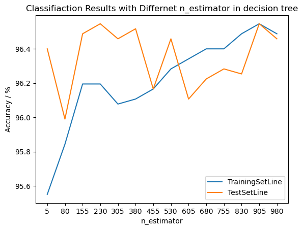

```python
#Classifer 8 Plot

fig, ax = plt.subplots()
df_results_list_dtTrain8.set_index("n_estimator")["Acc"].plot(ax = ax, label='TrainingSetLine')
df_results_list_dtTest8.set_index("n_estimator")["Acc"].plot(ax = ax, label='TestSetLine')
ax.set_title("Classifiaction Results with Differnet n_estimator in decision tree")
ax.set_xticks(list(range(5,1000,75)))
ax.set_ylabel("Accuracy / %")

ax.legend()

plt.show()
#validation accuracy comes from test set
```